# Praca domowa 2

Michał Stawikowski

15 - 11 - 2019

# 1 Wstęp

Celem tego raportu, będzie przedstawienie trzech różnych funkcji, których zadaniem jest przyjęcie jako argument zwykłej funkcji i zwrócenie jej wersji działającej w `NSE` - Non-standard evaluation. Na koniec porównamy szybkości działania różnych implementacji dla zróżnicowanych rozmiarów danych.

# 2 Implementacje

## 2.1 Implementacja pierwsza

Na początku napiszemy najprostszą funkcję wspierającą `NSE` i przetestujemy jej działanie.

Implementacja

```r
zadanieDomowe1 <- function(f){
  function(x, value, ...) {
    value_call <- substitute(value)
    arg_list <- eval(value_call, x)
    arg <- unlist(arg_list)
    f(arg, ...)
  }
}
```

oraz test:

```r
example_df <- data.frame(a = 1, b = c(1:5), c = list(a=1,b=2,c=3), f = 1:10)

minNSE <- zadanieDomowe1(min)

minNSE(example_df, b)
```

```
## [1] 1
```

Wygląda na to, że wszystko jest ok. Sprawdźmy jednak jeszcze raz na innym przykładzie:

```r
example_list <- list(a = 1, b = c(1:5), c = list(a=1,b=2,c=3), f = 1:10)
y <- 4
x <- 4


lmNSE <- zadanieDomowe1(lm)

lmNSE(example_list, a~y)
```

```
##
## Call:
## f(formula = arg)
##
## Coefficients:
## (Intercept)            y
##           1           NA
```

Nadal dobrze, ale teraz sprawdźmy dla `x`:

```r
lmNSE(example_list, a~x) #Ups
```

```
## Error in model.frame.default(formula = arg, drop.unused.levels = TRUE): niepoprawny typ (list) dla zmiennej 'x'
```

Żeby dowiedzieć się co poszło nie tak, musimy bliżej przyjrzeć się nazwom użytych zmiennych w funkcji `zadanieDomowe1`.

```r
zadanieDomowe1 <- function(f){
  function(x, value, ...) { #<-------- Jak widać tutaj też
    #siedzi nasz nieszczęsny 'x'
    value_call <- substitute(value)
    arg_list <- eval(value_call, x)
    arg <- unlist(arg_list)
    f(arg, ...)
  }
}
```

Możemy się łatwo domyślić co się popsuło. Nasza funkcja szukając zmiennej `x` na początku sprawdziła środowisko tej funkcji, niestety nasz `x` siedzi poza funkcją. Nie ma jednak co się załamywać, bo z pomocą przychodzi nam druga implementacja.

## 2.2 Implementacja druga

```r
zadanieDomowe2 <- function(f){
  function(x, value, ...) {
    value_call <- substitute(value)
    env <- list2env(x, parent = parent.frame()) # <--nowa linijka
    arg_list <- eval(value_call, env)
    arg <- unlist(arg_list)
    f(arg, ...)
  }
}
```

W celu uniknięcia błędu z poprzedniej funkcji tym razem będziemy trochę sprytniejsie i jako argument do funkcji `eval` przekażemy też środowisko rodzica jako `parent.frame()`. Sprawdźmy czy to pomoże.

```r
lmNSE <- zadanieDomowe2(lm)

lmNSE(example_list, a~x)
```

```
##
## Call:
## f(formula = arg)
##
## Coefficients:
## (Intercept)            x
##           1           NA
```

Tym razem wszystko poszło tak jak powinno. Możemy przejść do ostatnie implementacji.

## 2.3 Ostatnia Implementacja

```r
library(rlang)
zadanieDomowe3 <- function(f){
  function(x, value, ...) {
    value_call <- enquo(value) #<---- coś nowego
    arg <- eval_tidy(value_call,x) #<---- też coś nowego
    f(arg, ...)
  }
}
```

W tej implementacji skorzystaliśmy z pakietu `rlang` i zamiast funkcji `substitute` oraz `eval` skorzystaliśmy z `enquo` oraz `eval_tidy`. W uproszczeniu główną różnicą między enquo a substitute jest to, że pierwsza funkcja dodatkowo tworzy odniesienie do całego środowiska swojego argumentu, które może być zinterpetowane przez eval_tidy.

Sprawdźmy czy ta funkcja poradzi sobie z naszym podstępnym `x`-em.

```r
lmNSE <- zadanieDomowe3(lm)

lmNSE(example_list, a~x)
```

```
##
## Call:
## f(formula = arg)
##
## Coefficients:
## (Intercept)            x
##           1           NA
```

Udało się. Zatem teraz możemy przejść do porównywania szybkości naszych funkcji.

# 3 Benchmark

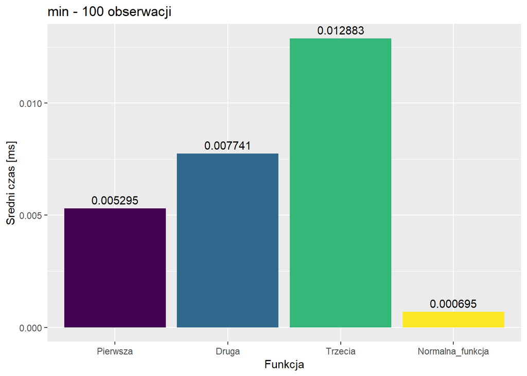

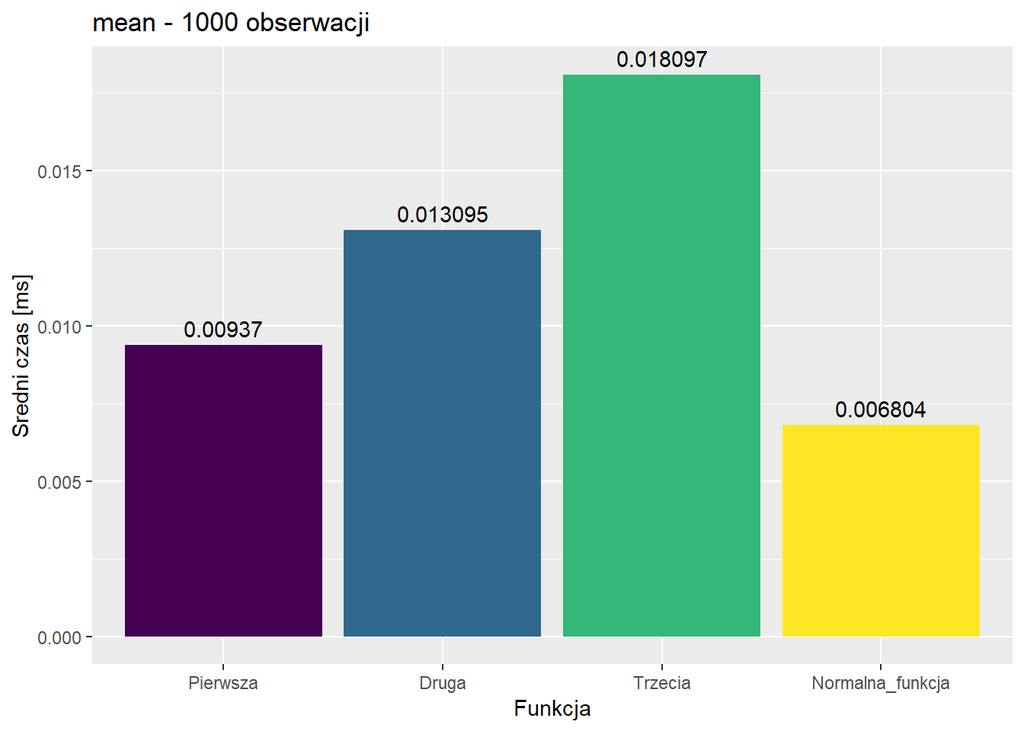

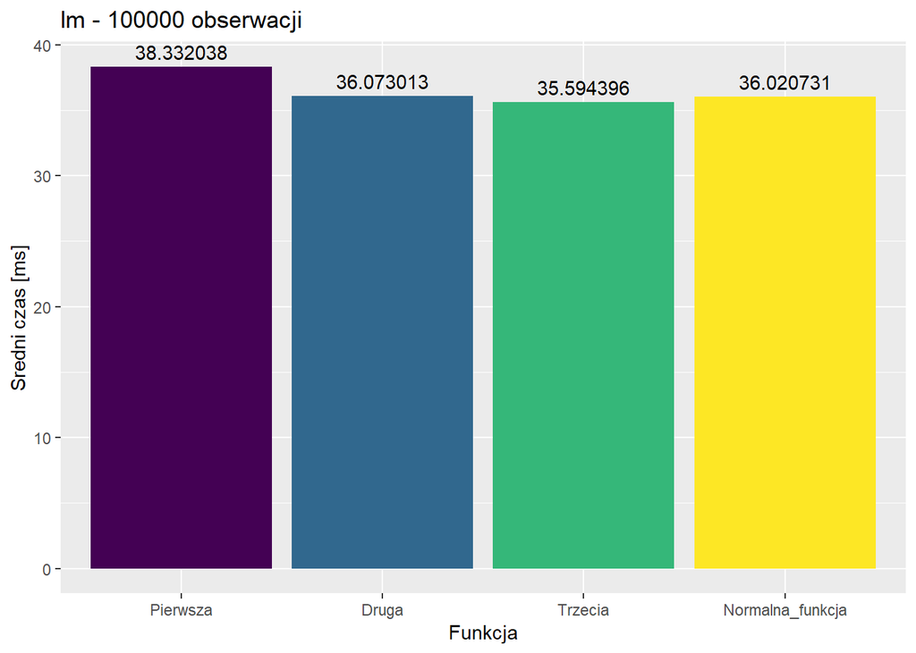

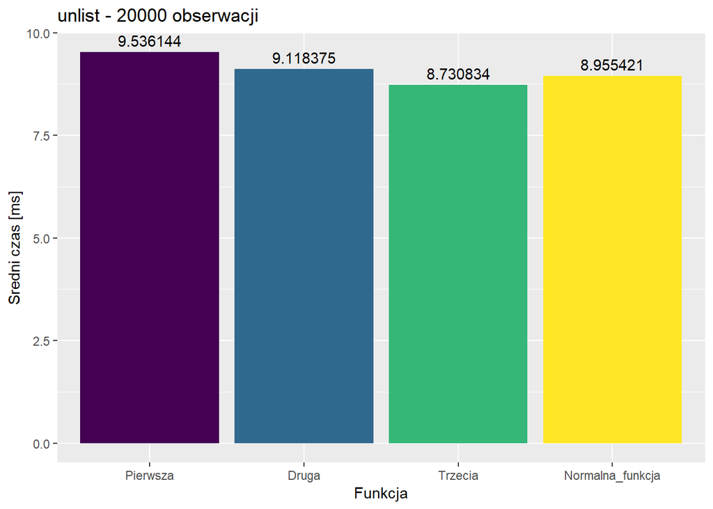

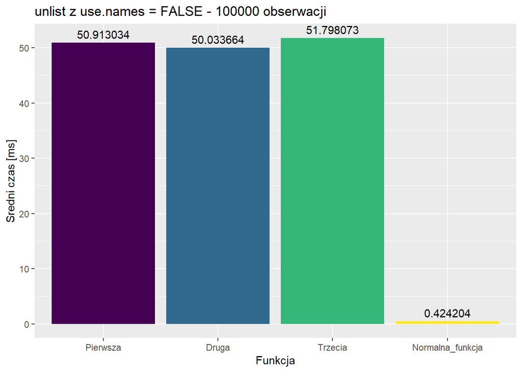

# 4 Wnioski

Dla funkcji `min` i `mean` i małej liczby obserwacji bez zaskoczenia zwykła funkcja radzi sobie najlepiej, zaś funckja używająca funkcji z biblioteki `rlang` najgorzej. Sytuacja zaskakująco zmienia się w przypadku funckji `lm` - gdzie zwykła funkcja (przy wywołaniu korzystającym z NSE) działa wolniej od funkcji z impletentacją z biblioteki `rlang` (może być to związane z implementacją NSE w lm). Interesujące jest też to, że czasami pierwsza funkcja jest szybsza od drugiej. Przy dużej ilości danych funkcje osiągają podobny czas wykonywania, choć na koniec czeka nas jeszcze jedna niespodzianka - zwykły unlist z use.name ustawionymi na FALSE bezlitośnie rozbił swoich oponentów